# Representativeness in Music Corpus Studes

2024-11-04

## Representativeness in Music Corpus Studies

### What’s at stake?

## Popular Music Artist Demographic Database

### Currently includes demographic info for the following databases

- *Rolling Stone 200* (2004 version) (de Clercq and Temperley 2011)
- *McGill Billboard Hot 100* (Burgoyne, Wild, and Fujinaga 2011)
- *Guitar Pro Tablature* (Shea 2023)
- *Timbre in Popular Song* (Reymore et al forthcoming; Shea et al 2024)
- *Rolling Stone 2021* (Shea et al 2024)

## Part 1: Diversity and representation

### A concern that demographic sampling isn’t representative

- sampling for artist diversity can skew inferences
- diversity is typically antithetical to effective representation, de Clercq (2023)

### *music-facing* corpus building (popularity)

- de Clercq (2023), “The population of glass vials […] has nothing to do with the population of people living in a country.”
- Songs as objects should be separate from the artists who created them

### *human-facing* corpus building (demographics)

- Shea et al (2024), genre is socially determined
- a song’s structural features interact with genre
- leverage the flexibility of genre toward socially just corpora

## What’s at stake when we build our corpora around one or the other?

### Does it make a difference statistically?

## Part 2: Model two approaches

### *music-facing*

- replicate de Clercq and Temperley’s approach (2011)
- *Rolling Stone Magazine’s* “500 Greatest Hits of All Time” (2004 version)
- expert perspective

### *human-facing*

- music cog researcher studying attention economy
- *Rolling Stone Magazine’s* “500 Greatest Hits of All Time” (2021 version)
- “more inclusive vision” of popular music post 2000s
- general listeners

## Part 2: introduction lengths

- *a few assumptions*
  - introductions, older songs > newer ones (Léveillé Gauvin 2016)
  - pre- and post-millennial formal features (Barna 2019)
- *sampling strategy*
  - 200 songs between 2004 and 2021 version
  - original distribution ( *RS200*) (popularity)
  - demographic proportion of artists per decade ( *RS2021*)(demographics)
- *Intro lengths encoded by grad students, $10/25 songs*
  - first audible sound to start of non-intro section
  - no intro at all? length = 0
  - assume lengths would be encoded after sampling
  - Cleaned/checked by NJS

## Part 3: Generating the Rolling Stone 200

### *RS5x20*, top 20 songs per decade [1/3]

```r
#read in database
RSall <- read.csv("RS2004-2021_intros.csv")
#make decade function by treating year as mod 10
floor_decade = function(value){ return(value - value %% 10) }
RSall$decade <- floor_decade(RSall$year)
#select 2004 version
RS2004 <- RSall %>%
  #select 2004 version
  filter(corpus == "2004")
```

## Part 3: Generating the Rolling Stone 200

### *RS5x20*, top 20 songs per decade [2/3]

```r
#generate the RS5x20
RS5x20 <- RS2004 %>%
  #group by decade
  group_by(decade) %>%
  #grab top 20 ratings
  arrange(desc(rank)) %>%
  #remove anything pre-1950 and post-2000
  filter(year > "1949", year < "2000") %>%
  slice(1:20)
```

## Part 3: Generating the Rolling Stone 200

### *RS200*, next 100 top-rated songs [3/3]

```r
#remove 5x20 from RS2004 so we don't sample it again
RS200 <- anti_join(RS2004,RS5x20) %>%
  #again remove decades out of scope
  filter(decade != "1940", decade != "2000") %>%
  #grab next 100 songs by rank
  arrange(desc(rank)) %>%
  slice(1:100)

#combine into one data set
RS200 <- rbind(RS200,RS5x20)
```

Now we have the *RS200* as TdC and DT compiled it

## Part 4: Attention economy study [1/2]

### Our music cognition researcher

- *hunch*: intro lengths decrease over time due to link between attention span and social media
- *question*: how does attention economy manifest in the general population?
- *prior knowledge*: listening habits are demographically coded (Nielsen reports, 2022)
- *sample*: *Rolling Stone Magazine* 2021 list
- *assumption*: artist compositional preferences in corpus reflect broader listening preferences
- *method*: align dataset diversity with population diversity per decade via Census data

## Part 4: Demographic terminology [2/2]

- generalize between white and non-white artists
  - listening habits are demographically encoded (Nielsen 2022)
  - problematically defers to hegemony of whiteness
  - US Census categories are inaccurate and can harm (Nobles 2000)
- BIHAP category
  - Black, Indigenous, Hispanic, Asian, and Pacific Islander
- Ideally we would have artists self report
  - *Institute for Composer Diversity* does this
  - I don’t have Beyonce’s number
  - rely on online databases instead

## Part 5: Generating a 200-song sample, *RS2021*

### Determine population distribution per decade [1/4]

```r
#determine proportion for RS2021
demo.table <- RSall %>%
  #filter to start at 1950
  filter(decade >= "1950") %>%
  #select 2021 version
  filter(corpus == "2021") %>%
  group_by(decade,BIHAP) %>%
  #count the number of artists per group, total number of artists
  dplyr::summarize(demo.count = n()) %>%
  dplyr::mutate(decade.count = sum(demo.count)) %>%
  #determine number of artists to sample per decade to maintain proportions
  dplyr::mutate(n.sample = round(decade.count*.4, digits = 0)) %>%
  mutate(RS2021 = round(demo.count/decade.count, digits = 3)) %>%
  filter(BIHAP == 1)
```

## Part 5: Generating a 200-song sample, *RS2021*

### Determine new population distribution [2/4]

```r
#read in Census data per decade
cen <- read.csv("US-Census-per-decade.csv")
cB <- cen$BIHAP
demo.table$census <- cB
n200<-demo.table$n.sample
#determine the number of artists needed to sample
#to maintain artist proportions/decade with Census
demo.table$n.BIHAP <- round(cB*n200, digits = 0)
demo.table$n.White <- round(n200-demo.table$n.BIHAP,digits = 0)
```

## Part 5: Generating a 200-song sample, *RS2021*

```r
print(demo.table)
```

```
## # A tibble: 8 × 9
## # Groups:   decade [8]
##   decade BIHAP demo.count decade.count n.sample RS2021 census n.BIHAP n.White
##    <dbl> <int>      <int>        <int>    <dbl>  <dbl>  <dbl>   <dbl>   <dbl>
## 1   1950     1         14           24       10  0.583  0.105       1       9
## 2   1960     1         46          108       43  0.426  0.114       5      38
## 3   1970     1         43          144       58  0.299  0.125       7      51
## 4   1980     1         34           81       32  0.42   0.169       5      27
## 5   1990     1         30           70       28  0.429  0.197       6      22
## 6   2000     1         22           36       14  0.611  0.249       3      11
## 7   2010     1         19           32       13  0.594  0.276       4       9
## 8   2020     1          3            3        1  1      0.384       0       1
```

## Sidebar: small sampling issue

- 2020 consists of all BIHAP artists
  - Megan Thee Stallion (Black, woman)
  - BTS (Korean, men)
  - Bad Bunny (Puerto Rican, man)
- Because the original sample size is so small (n = 3), it is mathematically impossible to maintain the proportion between BIHAP and white artists (of which there are none).
- To correct this, I’m going to modify `n.BIHAP` in the `demo.table` so that we can sample at least 2 artists.

```r
demo.table$n.BIHAP <- ifelse(demo.table$decade == "2020", 2, demo.table$n.BIHAP)
```

## Sidebar: small sampling issue

```r
demo.table
```

```
## # A tibble: 8 × 9
## # Groups:   decade [8]
##   decade BIHAP demo.count decade.count n.sample RS2021 census n.BIHAP n.White
##    <dbl> <int>      <int>        <int>    <dbl>  <dbl>  <dbl>   <dbl>   <dbl>
## 1   1950     1         14           24       10  0.583  0.105       1       9
## 2   1960     1         46          108       43  0.426  0.114       5      38
## 3   1970     1         43          144       58  0.299  0.125       7      51
## 4   1980     1         34           81       32  0.42   0.169       5      27
## 5   1990     1         30           70       28  0.429  0.197       6      22
## 6   2000     1         22           36       14  0.611  0.249       3      11
## 7   2010     1         19           32       13  0.594  0.276       4       9
## 8   2020     1          3            3        1  1      0.384       2       1
```

## Part 5: Generating a 200-song sample, *RS2021*

### compare proportions [3/4]

```r
#shape the data so we can easily compare prop between categories
#RS2021 versus Census proportion of BIHAP folks
prop.plot<-gather(data = demo.table, key = collection, value = prop, RS2021, census)
#generate the plot
prop.plot<-ggplot(prop.plot, aes(decade, prop, fill = collection)) +
  geom_col(position= "dodge")
#view the plot (next slide)
```

## Part 5: Population distributions

### *RS2021* versus *US Census* data [4/4]

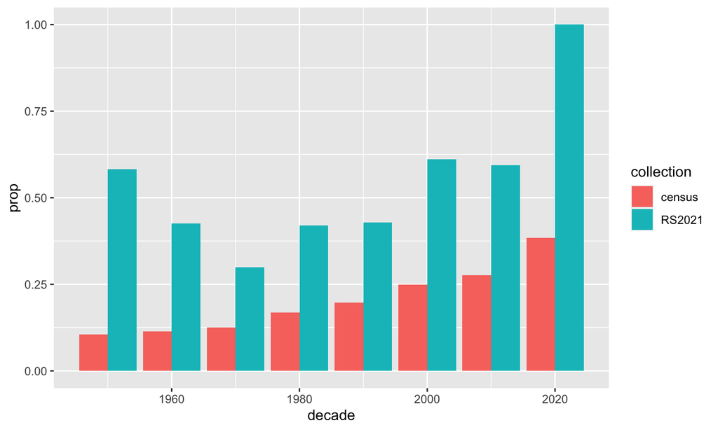

## Part 6: Stratified sampling in the literature

### Use in other disciplines [1/2]

*Stratified sampling* — data from an assumedly non-representative population is compiled then processed to become more representative “by adjusting the sample to have the same distribution of these variables as the population” (Alsati et al, 2023, p. 4)

A legitimate technique to address inherited biases in preexisting sources by aligning dataset diversity with real-world diversity.

## Part 6: Stratified sampling in the literature

### Examples [2/2]

- Wang et al (2015) predicted the results of the 2012 US presidential election from a demographically skewed sample of Xbox gamers.
  - disproportionately male
  - performed better than true probability or “raw” sampling

### Target a specific population

- Fareed et al (2022) compile, sort, and synthesize a variety of public databases to connect outreach organizations with Black mothers whose infants are at a nearly three times greater risk of premature death than white infants.
- Iterations of the Goldsmiths *Music Sophistication Index* have used post-hoc stratified sampling to adapt the index for various cultures (e.g., Lin et al, 2019; Degrave & Dedonder, 2019; Fiedler & Müllensiefen, 2015).

## Part 7: Stratified Sampling, *RS2021*

Create a 200-song sample from the 2021 version of the list.

Maintain demographic distribution of artists per decade based on Census data.

```r
#select the RS2021
RS2021 <- RSall %>%
  #select 2021 version
  filter(corpus == "2021")

#create an empty dataframe first
r2021_200 <- data.frame(matrix(ncol = 10, nrow = 0))
#set column names
x <- c("artist", "title", "primary.status", "BIHAP",
       "gender", "year", "corpus", "total", "rank", "decade")
colnames(r2021_200) <- x
```

## Part 7: Stratified Sampling, *RS2021*

```r
#begin for loop
for (i in 1:8)
{
#set decade for this iteration
d <- demo.table$decade[[i]]
#grab n artists per demographic group
no.b <- demo.table$n.BIHAP[[i]]
no.w <- demo.table$n.White[[i]]
#select the correct decade from the RS2021
rdec <- RS2021 %>% filter(decade == d)
#sample according to race/ethnicity distribution from demo.table
s.b <- stratified(rdec, c("BIHAP"), size = no.b, select = list(BIHAP = 1), replace = FALSE)
s.w <- stratified(rdec, c("BIHAP"), size = no.w, select = list(BIHAP = 0), replace = FALSE)
#join sample groups together
sample<-rbind(s.b,s.w)
#add to existing data frame
r2021_200<-rbind(r2021_200,sample)
}
```

## Part 8: Analysis

Predict changes in *intro length* (`total`) over time

Compare between samples from *RS200* and *RS2021* using a *linear model*

```r
#combine 200-song samples
RS <- rbind(r2021_200,RS200)
#make sure corpus is treated as a factor
RS$corpus <- as.factor(RS$corpus)
#plot differences based on linear model
lm.plot <- RS |>
  ggplot(aes(x = year, y = total, color = corpus )) +
  geom_point() +
  geom_smooth(method = "lm") +
  labs(title="Introduction lengths over time (RS2021, RS200); n = 200") +
  #"Cortez the Killer" by Neil Young has a 203-sec intro, let's limit y axis
  coord_cartesian(ylim = c(0,100), default = FALSE)
model <- lm(total ~ year*corpus, data = RS)
```

## Part 8: Analysis

### Linear model

```
##
## Call:
## lm(formula = total ~ year * corpus, data = RS)
##
## Residuals:
##     Min      1Q  Median      3Q     Max
## -29.276  -9.932  -5.048   4.929 183.533
##
## Coefficients:
##                  Estimate Std. Error t value Pr(>|t|)
## (Intercept)     -949.1553   256.1405  -3.706 0.000241 ***
## year               0.4904     0.1298   3.777 0.000183 ***
## corpus2021       592.6521   310.2168   1.910 0.056798 .
## year:corpus2021   -0.3007     0.1570  -1.915 0.056227 .
## ---
## Signif. codes:  0 '***' 0.001 '**' 0.01 '*' 0.05 '.' 0.1 ' ' 1
##
## Residual standard error: 19.42 on 396 degrees of freedom
## Multiple R-squared:  0.04613,    Adjusted R-squared:  0.0389
## F-statistic: 6.383 on 3 and 396 DF,  p-value: 0.0003117
```

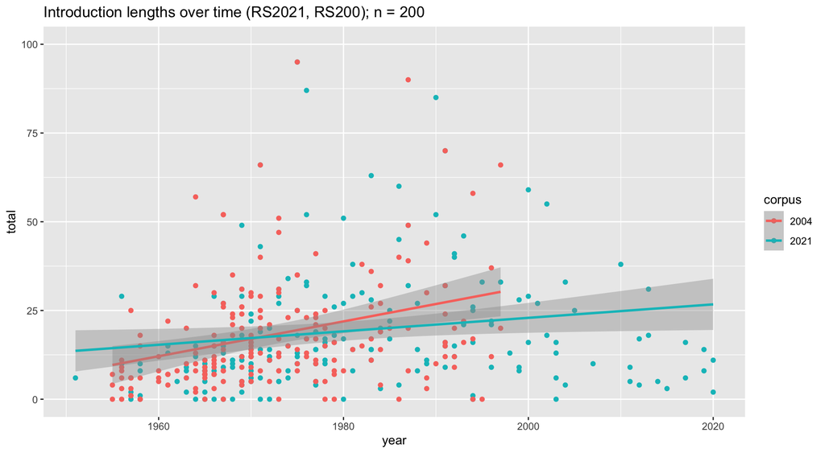

## Part 9: Results

So how can we interpret these results?

## Part 9: Caveats

In some ways we are comparing apples to oranges.

- The *RS200* prioritizes song rank. The *RS2021* is shaped around demographics.
- It would be productive to see if…
  - The complete *RS2004* reflects intro lengths by year if we shape the corpus by *demographics*.
  - The complete *RS2021* reflects intro lengths by year if we shape the corpus by *rank*.

## Part 10: Entire-corpora analysis

- Newest *Rolling Stone* list (2021) expands:
  - artists represented
  - chronological scope
  - BIHAP artists are “tacked on” pre-1950 and post-1999 (Shea et al 2024)

What’s the difference between the two (complete) lists?

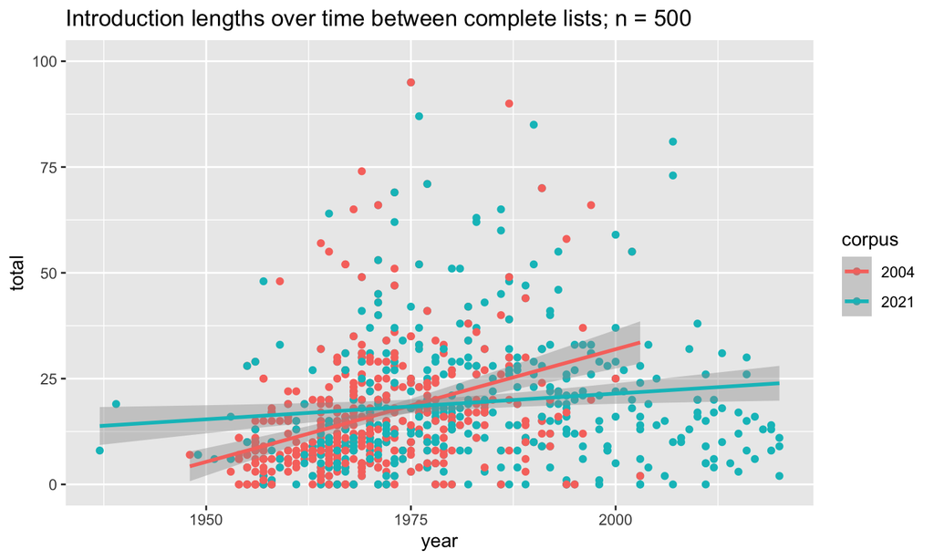

```r
RSall$corpus <- as.factor(RSall$corpus)
lm.plot <- RSall |>
  ggplot(aes(x = year, y = total, color = corpus)) +
  geom_point() +
  geom_smooth(method = "lm") +
  labs(title="Introduction lengths over time between complete lists; n = 500") +
  #"Cortez the Killer" by Neil Young has a 203-sec intro, let's limit y axis
  coord_cartesian(ylim = c(0,100), default = FALSE)
print(lm.plot)
```

## Part 11: Post-hoc analysis [2/8]

### Reshape the *n* = 200 sample for RS2021 by rank

```r
#generate the RS5x20
RS5x20_21 <- RS2021d %>%
  #group by decade
  group_by(decade) %>%
  #grab top 20 ratings
  arrange(desc(rank)) %>%
  #remove anything pre-1950 and post-2000
  filter(year > "1949", year < "2000") %>%
  slice(1:20)
```

## Part 11: Post-hoc analysis [3/8]

### Reshape the *n* = 200 sample for RS2021 by rank

```r
#remove 5x20 from RS2004 so we don't sample it again
RS2021_100 <- anti_join(RS2021d,RS5x20_21) %>%
  #again remove decades out of scope
  filter(decade != "1940", decade != "2000") %>%
  #grab next 100 songs by rank
  arrange(desc(rank)) %>%
  slice(1:100)

#combine into one data set
RS2021_200 <- rbind(RS2021_100,RS5x20_21)
rm(RS2021d,RS5x20_21)
```

## Part 11: Post-hoc analysis [4/8]

### Reshape the *n* = 200 sample for RS2004 by *demographics*

```r
#determine proportion for RS2021
demo.table <- RSall %>%
  #filter to start at 1950
  filter(decade >= "1950", year <= "2004") %>%
  #select 2021 version
  filter(corpus == "2004") %>%
  group_by(decade,BIHAP) %>%
  #count the number of artists per group, total number of artists
  dplyr::summarize(demo.count = n()) %>%
  dplyr::mutate(decade.count = sum(demo.count)) %>%
  #determine number of artists to sample per decade to maintain proportions
  dplyr::mutate(n.sample = round(decade.count*.4, digits = 0)) %>%
  mutate(RS2021 = round(demo.count/decade.count, digits = 3)) %>%
  filter(BIHAP == 1)
```

## Part 11: Post-hoc analysis [5/8]

### Reshape the *n* = 200 sample for RS2004 by *demographics*

```r
#select the RS2021
RS2004 <- RSall %>%
  #select 2021 version
  filter(corpus == "2004")

#create an empty dataframe first
r2004_200 <- data.frame(matrix(ncol = 10, nrow = 0))
#set column names
x <- c("artist", "title", "primary.status", "BIHAP",
       "gender", "year", "corpus", "total", "rank", "decade")
colnames(r2004_200) <- x
```

## Part 11: Post-hoc analysis [6/8]

### Reshape the *n* = 200 sample for RS2004 by *demographics*

```r
#read in Census data per decade
cen <- read.csv("US-Census-per-decade.csv")
cen <- cen %>% filter(Decade != "2010", Decade != "2020")
cB <- cen$BIHAP
demo.table$census <- cB
n200<-demo.table$n.sample
#determine the number of artists needed to sample
#to maintain artist proportions/decade with Census
demo.table$n.BIHAP <- round(cB*n200, digits = 0)
demo.table$n.White <- round(n200-demo.table$n.BIHAP,digits = 0)
```

## Part 11: Post-hoc analysis [7/8]

### Reshape the *n* = 200 sample for RS2004 by *demographics*

```r
#begin for loop
for (i in 1:6)
{
#set decade for this iteration
d <- demo.table$decade[[i]]
#grab n artists per demographic group
no.b <- demo.table$n.BIHAP[[i]]
no.w <- demo.table$n.White[[i]]
#select the correct decade from the RS2021
rdec <- RS2004 %>% filter(decade == d)
#sample according to race/ethnicity distribution from demo.table
s.b <- stratified(rdec, c("BIHAP"), size = no.b, select = list(BIHAP = 1), replace = FALSE)
s.w <- stratified(rdec, c("BIHAP"), size = no.w, select = list(BIHAP = 0), replace = FALSE)
#join sample groups together
sample<-rbind(s.b,s.w)
#add to existing data frame
r2004_200<-rbind(r2004_200,sample)
}
```

## Part 11: Post-hoc analysis [8/8]

```r
#combine 200-song samples
RS <- rbind(r2021_200,r2004_200)
#make sure corpus is treated as a factor
RS$corpus <- as.factor(RS$corpus)
#plot differences based on linear model
lm.plot <- RS |>
  ggplot(aes(x = year, y = total, color = corpus )) +
  geom_point() +
  geom_smooth(method = "lm") +
  labs(title="Introduction lengths over time (RS2021, RS2004); n = 200",
       subtitle="RS2021 = rank, RS2004 = demographics") +
  #"Cortez the Killer" by Neil Young has a 203-sec intro, let's limit y axis
  coord_cartesian(ylim = c(0,100), default = FALSE)
RS$corpus <- as.factor(RS$corpus)
RS$total <- as.numeric(RS$total)
RS$year <- as.numeric(RS$year)
model <- lm(total ~ year*corpus, data = RS)
```

## Part 11: Post-hoc analysis [8/8]

```
##
## Call:
## lm(formula = total ~ year * corpus, data = RS)
##
## Residuals:
##     Min      1Q  Median      3Q     Max
## -29.327  -9.802  -4.807   4.201 183.193
##
## Coefficients:
##                  Estimate Std. Error t value Pr(>|t|)
## (Intercept)     -969.8384   281.3910  -3.447 0.000629 ***
## year               0.5011     0.1428   3.509 0.000502 ***
## corpus2021       613.3352   330.0055   1.859 0.063833 .
## year:corpus2021   -0.3114     0.1672  -1.862 0.063365 .
## ---
## Signif. codes:  0 '***' 0.001 '**' 0.01 '*' 0.05 '.' 0.1 ' ' 1
##
## Residual standard error: 19.13 on 395 degrees of freedom
## Multiple R-squared:  0.04351,    Adjusted R-squared:  0.03625
## F-statistic:  5.99 on 3 and 395 DF,  p-value: 0.0005331
```

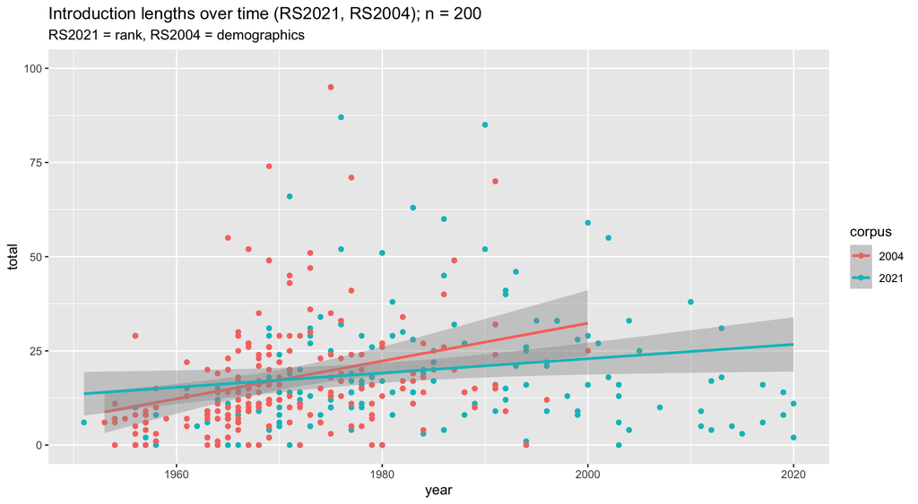

## Part 12: Discussion

### **Discussion questions**

Is the new *RS* list as “representative” as the older version? Why or why not?

- How do we tend to treat genre in music theory?
- Do artist identities correspond to, or perhaps influence, feature organization?
- What else may be at play to cause differences between the two lists?

## Works cited

See handout. Couldn’t get the formatting right on here ¯_(ツ)_/¯